# Perceived AI Threat by Coders

# Research Design

## Data Overview

The data is the Stack Overflow 2024 developer survey. This survey is conducted yearly and administered to stack overflow users. This means the sample is explicitly contained to stack overflow. That does not necessarily denote professional developers however, and also covered a wide range of anyone who codes. It includes questions about preferred tooling, enjoyment of career and work, and challenges professional coders face. I expect the sample is supposed to generalize to coders, with a general focus on software engineering vs say data workers based on the questions asked.

## Variable Overview

DV: This is whether coders view AI as a threat or not to their current job. It has three options: yes, no, and I’m not sure, with the latter filtered out as a non substantial answer. Since part of the hypothesis proposed here is how the DV varies by country and there are a lot of countries multilevel modeling will be used to estimate the effects of the IVs on the DV. Both an OLS and Logit model will be fit and the better model will be used for interpretation. OLS will be used since it is the traditional and more easily interpretable choice and Logit because the DV is coded as binary after removal of insubstantial responses.

- IVs:
  - Years of coding professionally: A continuous variable denoting how long one has been coding professionally
- Controls:
  - Education Level: categorical / factor ranging from primary school to professional degrees; demographic control
  - Age: categorical / factor, youngest group is <18 oldest is >65; demographic control
  - AI Sentiment: Likert scale 1-5 (actually 6 but unsubstantial). Stance on using AI tools in workflow, higher is more favorable, don’t want this as a component of years coding
  - AI Complexity: Likert scale 1-5. How well one respondent trusts AI for complex tasks higher is more favorable; included for the same reason as AI sentiment
- Grouping:
  - Country: country of residence for respondent

Notably the responses for the DV are incredibly imblanaced

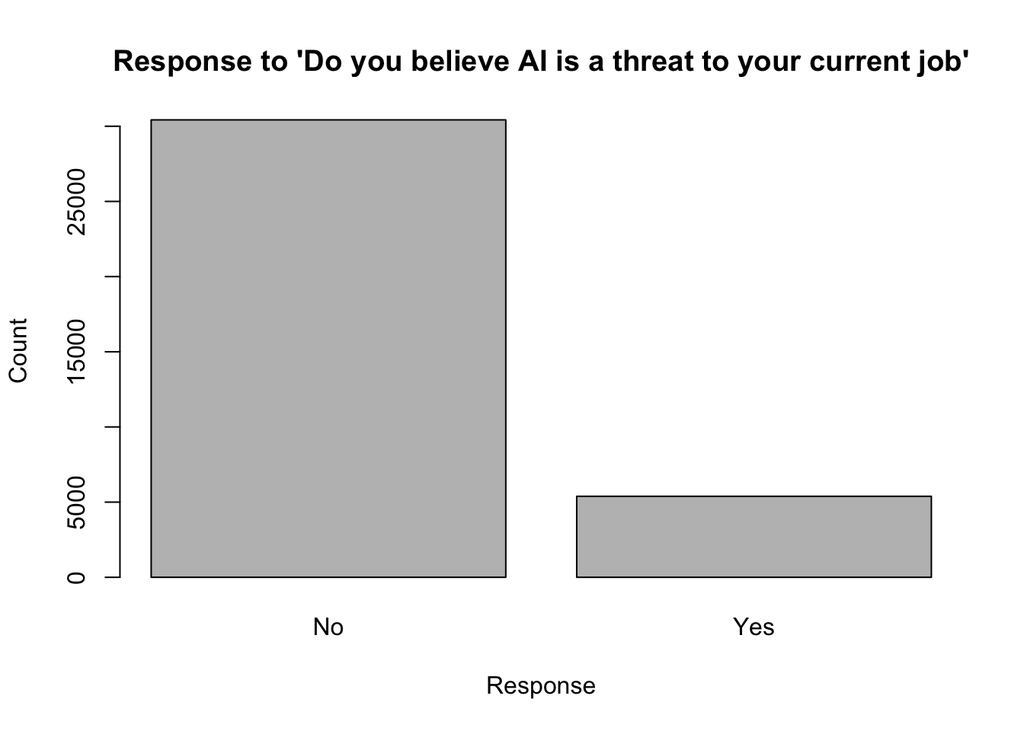

```r
barplot(table(data_edit$ai_threat), ylab = "Count", xlab = "Response", names.arg = c("No", "Yes"))
title("Response to 'Do you believe AI is a threat to your current job'")
```

```
Mean of AI Threat Responses 0.150456563625702
```

```
Variance of AI Threat Responses 0.127822955464472
```

```
Number of countries in sample: 181
```

```r
skim(data_edit)
```

Data summary

| Name | data_edit |
| --- | --- |
| Number of rows | 35811 |
| Number of columns | 7 |
| _______________________ |  |
| Column type frequency: |  |
| character | 1 |
| factor | 2 |
| numeric | 4 |
| ________________________ |  |
| Group variables | None |

**Variable type: character**

| skim_variable | n_missing | complete_rate | min | max | empty | n_unique | whitespace |
| --- | --- | --- | --- | --- | --- | --- | --- |
| country | 957 | 0.97 | 4 | 52 | 0 | 180 | 0 |

**Variable type: factor**

| skim_variable | n_missing | complete_rate | ordered | n_unique | top_counts |
| --- | --- | --- | --- | --- | --- |
| age | 108 | 1.00 | FALSE | 7 | 25-: 13650, 35-: 8280, 18-: 7385, 45-: 3505 |
| ed_level | 1170 | 0.97 | FALSE | 7 | Bac: 14728, Mas: 9174, Som: 4334, Sec: 3116 |

**Variable type: numeric**

| skim_variable | n_missing | complete_rate | mean | sd | p0 | p25 | p50 | p75 | p100 | hist |
| --- | --- | --- | --- | --- | --- | --- | --- | --- | --- | --- |
| years_code_pro | 5210 | 0.85 | 9.84 | 8.75 | 0 | 3 | 7 | 14 | 50 | ▇▃▁▁▁ |
| ai_sent | 969 | 0.97 | 3.90 | 0.88 | 1 | 3 | 4 | 4 | 5 | ▁▁▃▇▅ |
| ai_complex | 6780 | 0.81 | 2.81 | 1.12 | 1 | 2 | 3 | 4 | 5 | ▃▇▅▇▁ |
| ai_threat | 0 | 1.00 | 0.15 | 0.36 | 0 | 0 | 0 | 0 | 1 | ▇▁▁▁▂ |

```r
icc_mod_lm <- lmer(
  ai_threat ~ +
    (1 |country),
  data = data_edit
)
```

```r
icc_mod_logit <- glmer(
  ai_threat ~ +
    (1 |country),
  data = data_edit,
  family = binomial(link = "logit")
)
```

## Interclass Correlation

```r
tab_model(
  transform = NULL,
  icc_mod_lm,
  icc_mod_logit,
  title = "ICC Models",
  dv.labels = c("Linear Model", "Logit Model"),
  show.icc = T
)
```

ICC Models

|  | Linear Model |  |  | Logit Model |  |  |
| --- | --- | --- | --- | --- | --- | --- |
| Predictors | Estimates | CI | p | Log-Odds | CI | p |
| (Intercept) | 0.16 | 0.15 – 0.17 | **<0.001** | -1.71 | -1.80 – -1.62 | **<0.001** |
| Random Effects |  |  |  |  |  |  |
| σ<sup>2</sup> | 0.12 |  |  | 3.29 |  |  |
| τ<sub>00</sub> | 0.00 <sub>country</sub> |  |  | 0.16 <sub>country</sub> |  |  |
| ICC | 0.02 |  |  | 0.05 |  |  |
| N | 180 <sub>country</sub> |  |  | 180 <sub>country</sub> |  |  |
| Observations | 34854 |  |  | 34854 |  |  |
| Marginal R<sup>2</sup> / Conditional R<sup>2</sup> | 0.000 / 0.024 |  |  | 0.000 / 0.046 |  |  |

With extremely low interclass correlation (ICC) values, varying intercept is what will be used for the multilevel model. Low ICC indicates that there isn’t much variance between groupings indicating MLM isn’t strictly necessary, however using it will make country differences much more interpretable.

## Model Fitting

```r
lm_mod <- lmer(
  ai_threat ~
    age +
    ed_level +
    years_code_pro +
    ai_sent +
    ai_complex +
    (1|country),
  data = data_edit
)
```

```r
logit_mod <- glmmTMB(
  ai_threat ~
    age +
    ed_level +
    years_code_pro +
    ai_sent +
    ai_complex +
    (1|country),
  data = data_edit,
  family = binomial(link = "logit")
)
```

## Linear vs Logit Model Comparison

```r
tab_model(
  transform = NULL,
  lm_mod,
  logit_mod,
  title = "Varying Intercept Models for Perceived AI Threat by Stack Overflow Developers",
  dv.labels = c("Linear Model Varying Intercept (AI Threat)", "Logit Model Varying Intercept(AI Threat)"),
  pred.labels = c(
    "(Intercept)",
    "18-24 Years Old",
    "25-34 Years Old",
    "35-44 Years Old",
    "45-54 Years Old",
    "55-64 Years Old",
    "65 Years or Older",
    "Secondary School",
    "Some College",
    "Associate",
    "Bachelor's",
    "Master's",
    "Professional Degree",
    "Years Coding Professionally",
    "AI Sentiment",
    "Trust in AI for Complex Tasks"
  ),
  show.loglik = T,
  show.aic = T,
  show.r2 = F
)
```

Varying Intercept Models for Perceived AI Threat by Stack Overflow Developers

|  | Linear Model Varying Intercept (AI Threat) |  |  | Logit Model Varying Intercept(AI Threat) |  |  |
| --- | --- | --- | --- | --- | --- | --- |
| Predictors | Estimates | CI | p | Log-Odds | CI | p |
| (Intercept) | 0.17 | 0.10 – 0.24 | **<0.001** | -1.70 | -2.22 – -1.18 | **<0.001** |
| 18-24 Years Old | -0.01 | -0.06 – 0.04 | 0.768 | -0.05 | -0.45 – 0.35 | 0.811 |
| 25-34 Years Old | 0.01 | -0.04 – 0.06 | 0.807 | 0.07 | -0.34 – 0.47 | 0.751 |
| 35-44 Years Old | 0.04 | -0.01 – 0.09 | 0.141 | 0.34 | -0.07 – 0.76 | 0.103 |
| 45-54 Years Old | 0.07 | 0.01 – 0.12 | **0.019** | 0.57 | 0.13 – 1.01 | **0.011** |
| 55-64 Years Old | 0.05 | -0.01 – 0.11 | 0.112 | 0.38 | -0.12 – 0.89 | 0.140 |
| 65 Years or Older | 0.04 | -0.04 – 0.13 | 0.310 | 0.26 | -0.54 – 1.06 | 0.522 |
| Secondary School | -0.05 | -0.10 – 0.01 | 0.093 | -0.33 | -0.73 – 0.07 | 0.110 |
| Some College | -0.05 | -0.10 – 0.00 | 0.054 | -0.37 | -0.77 – 0.02 | 0.062 |
| Associate | -0.04 | -0.10 – 0.02 | 0.164 | -0.28 | -0.71 – 0.15 | 0.197 |
| Bachelor's | -0.06 | -0.11 – -0.01 | **0.031** | -0.42 | -0.80 – -0.03 | **0.034** |
| Master's | -0.07 | -0.12 – -0.01 | **0.014** | -0.49 | -0.88 – -0.10 | **0.014** |
| Professional Degree | -0.10 | -0.15 – -0.04 | **0.001** | -0.79 | -1.22 – -0.36 | **<0.001** |
| Years Coding Professionally | -0.00 | -0.00 – -0.00 | **<0.001** | -0.03 | -0.03 – -0.02 | **<0.001** |
| AI Sentiment | -0.00 | -0.01 – 0.00 | 0.354 | -0.02 | -0.07 – 0.03 | 0.402 |
| Trust in AI for Complex Tasks | 0.02 | 0.01 – 0.02 | **<0.001** | 0.15 | 0.11 – 0.19 | **<0.001** |
| Random Effects |  |  |  |  |  |  |
| σ<sup>2</sup> | 0.12 |  |  | 3.29 |  |  |
| τ<sub>00</sub> | 0.00 <sub>country</sub> |  |  | 0.13 <sub>country</sub> |  |  |
| ICC | 0.02 |  |  | 0.04 |  |  |
| N | 168 <sub>country</sub> |  |  | 168 <sub>country</sub> |  |  |
| Observations | 24208 |  |  | 24208 |  |  |
| AIC | 17348.314 |  |  | 19356.142 |  |  |
| log-Likelihood | -8656.157 |  |  | -9661.071 |  |  |

## Top and Bottom 5 Countries by Intercept

```r
country_re <- round(ranef(lm_mod)$country, digits = 3)

country_re_df <- as_tibble(country_re, rownames = "country")

ordered_re <- country_re_df %>%
  arrange(desc(`(Intercept)`))

ranked_re <- ordered_re %>%
  mutate(rank = row_number())

bottom_5_ranked <- head(ranked_re, 5)
top_5_ranked <- tail(ranked_re, 5)

top_bottom_10_ranked <- bind_rows(top_5_ranked, bottom_5_ranked) %>%
  arrange(rank)

kable(top_bottom_10_ranked, caption = "Top and Bottom 5 Country Intercepts")
```

Top and Bottom 5 Country Intercepts

| country | (Intercept) | rank |
| --- | --- | --- |
| South Korea | 0.125 | 1 |
| Iran, Islamic Republic of… | 0.110 | 2 |
| Republic of Korea | 0.086 | 3 |
| Viet Nam | 0.083 | 4 |
| Turkey | 0.078 | 5 |
| Slovenia | -0.053 | 164 |
| Denmark | -0.054 | 165 |
| Croatia | -0.060 | 166 |
| Austria | -0.061 | 167 |
| Finland | -0.061 | 168 |